# R Notebook

#Universal mammalian clock2 of age # #author for developing clock2: Ake T. Lu #author for developing clock1 and clock3: Zhe Fei #

```r
rm(list=ls())
options(stringsAsFactors = F)
setwd('/Users/alu/Desktop')
myinput.list=readRDS('mydata_GitHub.Rds')
```

# The following labels the coefficient values of the three universal clocks

```r
beta.name=c('beta_clock1','beta_clock2','beta_clock3')
y.name=c('Y.pred1','Y.pred2','Y.pred3')
age.name=c('DNAmAgePanMammalianClock1','DNAmAgePanMammalianClock2','DNAmAgePanMammalianClock3')
```

#clock2

```r
F2_antitrans_clock2<-function(y,y.maxAge,y.gestation,const=1){
  x0=const*exp(-exp(-1*y))
  x1=x0*(y.maxAge+y.gestation)
  x=x1-y.gestation
  x
}
```

#clock3 #

```r
F1_logli <- function(age1, m1, m2 = m1, c1=1){
  ifelse(age1 >= m1, (age1-m1)/m2 , c1*log((age1-m1)/m2/c1 +1) )
}
#RelativeAdultAge
F2_revtrsf_clock3 <- function(y.pred, m1, m2 = m1, c1=1){
  ifelse(y.pred<0, (exp(y.pred/c1)-1)*m2*c1 + m1, y.pred*m2+m1 )
}
```

# The `loglifn` function shows how to calculate m1 for the transformation

# It is the `a_Logli` in the function

```r
F3_loglifn = function(dat1,b1=1,max_tage = 4,
                      c1=5, c2 = 0.38, c0=0){
  n=nrow(dat1)

  age1 = (dat1$maxAge+dat1$GestationTimeInYears)/(dat1$averagedMaturity.yrs+dat1$GestationTimeInYears)

  a1 = age1/(1+max_tage)
  dat1$a1_Logli = a1 #x/m1 in manuscript

  a2 = (dat1$GestationTimeInYears + c0)/(dat1$averagedMaturity.yrs)
  dat1$a_Logli = a_Logli = c1*a2^c2
  #m=5*(G/ASM)^0.38 from regression analysis/formula(7)


  x = dat1$Age + dat1$GestationTimeInYears
  t2 = dat1$averagedMaturity.yrs*b1 + dat1$GestationTimeInYears
  x2 = x/t2 #### log(x/t2)
  y = F1_logli(x2, a_Logli, a_Logli)

  dat1$LogliAge <- y
  return(dat1)
}
```

#(1)generate variable HighmaxAge

```r
names(myinput.list)
```

```
## [1] "SampleAnnotation"                 "meth_betas"
## [3] "anAge"                            "ThreeUniversalPanMammalianClocks"
```

```r
info=myinput.list[[1]]#The only required variables are SpeciesLatinName and Basename
anage=myinput.list[[3]]
info=merge(by='SpeciesLatinName',info,subset(anage,select=c(SpeciesLatinName,GestationTimeInYears,
                                                             averagedMaturity.yrs,maxAge)))
head(info)
```

|  | SpeciesLatinName | Basename | MammalNumberHorvath | SpeciesCommonName | Age | Female | Tissue | GestationTimeInYears | averagedMaturity.yrs | maxAge |
| --- | --- | --- | --- | --- | --- | --- | --- | --- | --- | --- |
| 1 | Tursiops truncatus | 202894750036_R05C02 | 4.13.6 | Bottlenose dolphin | 11.42 | 0 | Blood | 1.030137 | 8.931507 | 67 |
| 2 | Tursiops truncatus | 202897220027_R01C02 | 4.13.6 | Bottlenose dolphin | 15.44 | 1 | Blood | 1.030137 | 8.931507 | 67 |
| 3 | Tursiops truncatus | 202897220027_R02C02 | 4.13.6 | Bottlenose dolphin | 19.30 | 1 | Blood | 1.030137 | 8.931507 | 67 |
| 4 | Tursiops truncatus | 202897220027_R06C01 | 4.13.6 | Bottlenose dolphin | 18.23 | 1 | Blood | 1.030137 | 8.931507 | 67 |
| 5 | Tursiops truncatus | 202897220040_R02C01 | 4.13.6 | Bottlenose dolphin | 14.66 | 1 | Blood | 1.030137 | 8.931507 | 67 |
| 6 | Tursiops truncatus | 202897220040_R06C01 | 4.13.6 | Bottlenose dolphin | 28.27 | 0 | Blood | 1.030137 | 8.931507 | 67 |

#Description for mymax=1.3 #We were concerned that the uneven evidence surrounding the maximum age of different species #could bias our analysis. While billions of people have been evaluated for estimating #the maximum age of humans (122.5 years) or mice (4 years), #the same cannot be said for any other species. #To address this concern, we made the following assumption: #the true maximum age is 30% higher than that reported in AnAge #for all species except for humans and mice (Mus musculus). #Therefore, we multiplied the reported maximum lifespan of non-human or non-mouse species by 1.3. #Our predictive models turn out to be highly robust with respect to this assumption.

```r
MYMAX=1.3
info$HighmaxAge=MYMAX*info$maxAge
info$HighmaxAge[info$SpeciesLatinName=='Homo sapiens']=info$maxAge[info$SpeciesLatinName=='Homo sapiens']
info$HighmaxAge[info$SpeciesLatinName=='Mus musculus']=info$maxAge[info$SpeciesLatinName=='Mus musculus']
```

#(2)merge info and metharray beta values

```r
glmnet.list=myinput.list[[4]]#The three universal clock prediction models
mycpgs=c(glmnet.list[[1]]$var,glmnet.list[[2]]$var,glmnet.list[[3]]$var)
mycpgs=unique(mycpgs)
mycpgs=mycpgs[mycpgs!='Intercept']

#dat.meth0: number of Mammalian array CpGs (n=37554) x [number of samples+1]
#
dat.meth0=myinput.list[[2]]
dat.meth0=subset(dat.meth0,CGid%in%mycpgs)#only keep the CpGs in the three clocks
dat.meth=t(dat.meth0[,-c(1)])
colnames(dat.meth)=dat.meth0$CGid
dat.meth=data.frame(Basename=colnames(dat.meth0)[-c(1)],dat.meth)
dat.meth$Intercept=1
#
info=merge(by='Basename',info,dat.meth)
#
#predict RelativeAge
#

for(k in 1:3){
glmnet=glmnet.list[[k]]
glmnet$beta=glmnet[,beta.name[k]]
#glmnet$var[1]=ifelse(glmnet$var[1]=="(Intercept)",'Intercept',glmnet$var[1])
temp=as.matrix(subset(info,select=as.character(glmnet$var)))
info[,y.name[k]]=as.numeric(as.matrix(subset(info,select=as.character(glmnet$var)))%*%glmnet$beta)
}
```

#(1) Clock 1

```r
info[,age.name[1]]=exp(info[,y.name[k]])-2
```

#(2) Clock 2

```r
info$DNAmRelativeAge=exp(-exp(-1*info[,y.name[2]]))
info[,age.name[2]]= F2_antitrans_clock2(info[,y.name[2]],info$HighmaxAge,info$GestationTimeInYears,const=1)
```

#(3) Clock 3

```r
info=F3_loglifn(info)#to compute m estimate for tuning point in the log-linear transformation
info$m1=info$a_Logli
info$DNAmRelativeAdultAge=F2_revtrsf_clock3(info[,y.name[3]], info$m1)
info[,age.name[3]]<-
  info$DNAmRelativeAdultAge *(info$averagedMaturity.yrs + info$GestationTimeInYears) -info$GestationTimeInYears
```

#output

```r
output=subset(info,select=c('Basename','SpeciesLatinName','MammalNumberHorvath','Age','Tissue','DNAmRelativeAge','DNAmRelativeAdultAge',age.name))
```

#plot

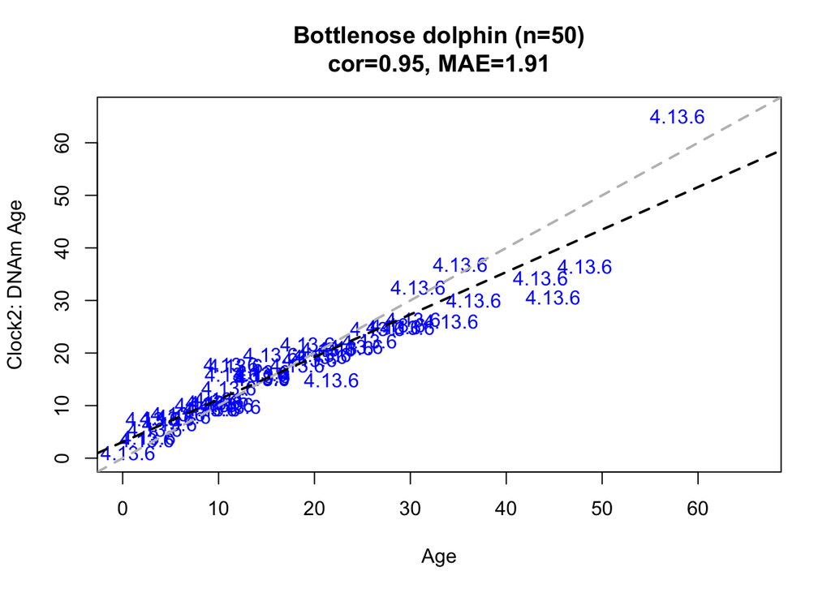

```r
x=output$Age
y=output$DNAmAgePanMammalianClock2
cor0=round(cor(x,y),2)
mae0=round(median(abs(x-y)),2)
plot(x,y,xlab='Age',ylab='Clock2: DNAm Age',
     main=paste0('Bottlenose dolphin (n=',length(x),')\n','cor=',cor0,
                 ', MAE=',mae0),
     col='white',xlim=c(0,max(max(x),max(y))+1),
     ylim=c(0,max(max(x),max(y))+1))
text(x,y,label=output$MammalNumberHorvath,col='blue')
abline(0,1,lwd=2,lty=2,col="grey")
model1=lm(y~x)
abline(model1,lwd=2,lty=2,col='black')
```